# Airline Business Analysis and future prediction based on passengers' satisfaction

## Project 2 for Group 8:

### Team members: Sahand Yousefi- Siddharth Dwivedi

#### Data: https://www.kaggle.com/teejmahal20/airline-passenger-satisfaction

# Abstract

### A. Descriptive Questions:

Our first question(Descriptive) based on the dataset that we have is:

- Could airline to get acceptable level of satisfaction of its customers?
- which factor had more effect on customers' satisfaction?

### B. Diagnostic Questions:

and our Diagnostic question is:

- why some factors like drink and food or distances had effect on customers' satisfaction?
- our statistical analysis like variance analysis can be efficient to explain the trend of satisfaction, or not?

##### Note:

In the Kaggle the name of dataset is mentioned "train" while the dataset is for airline and airplains, so we changed the name to "airline"

# 1. Introduction

#### As the infromation that explained in abstract, dataset is for an airline passengers evaluated their satisfaction level in terms of some features which are listed below:

- Gender: Gender of the passengers (Female, Male)
- Customer Type: The customer type (Loyal customer, disloyal customer)
- Age: The actual age of the passengers
- Type of Travel: Purpose of the flight of the passengers (Personal Travel, Business Travel)
- Class: Travel class in the plane of the passengers (Business, Eco, Eco Plus)
- Flight distance: The flight distance of this journey
- Inflight wifi service: Satisfaction level of the inflight wifi service (0:Not Applicable;1-5)
- Departure/Arrival time convenient: Satisfaction level of Departure/Arrival time convenient
- Ease of Online booking: Satisfaction level of online booking
- Gate location: Satisfaction level of Gate location
- Food and drink: Satisfaction level of Food and drink
- Online boarding: Satisfaction level of online boarding
- Seat comfort: Satisfaction level of Seat comfort
- Inflight entertainment: Satisfaction level of inflight entertainment
- On-board service: Satisfaction level of On-board service
- Leg room service: Satisfaction level of Leg room service
- Baggage handling: Satisfaction level of baggage handling
- Check-in service: Satisfaction level of Check-in service
- Inflight service: Satisfaction level of inflight service
- Cleanliness: Satisfaction level of Cleanliness
- Departure Delay in Minutes: Minutes delayed when departure
- Arrival Delay in Minutes: Minutes delayed when Arrival
- Satisfaction: Airline satisfaction level(Satisfaction, neutral or dissatisfaction)

# 2. Main (Analysis)

# 2.1 First phase: "Check"

In this part, we provide the basic information related to our dataset for better presentation and identify suitable manners to analayze them. Due to this, dataset is called and shown in terms of:

- head
- tail
- shape
- columns
- values
- data types
- info
- describe

```python
# Importing libraries

import numpy as np
import pandas as pd
import seaborn as sns
import matplotlib.pyplot as plt
from matplotlib.ticker import StrMethodFormatter
```

```python
# importing our dataset

raw="/home/sahand/Desktop/airline.csv"
df=pd.read_csv(raw)
df.head()
```

|  | Unnamed: 0 | id | Gender | Customer Type | Age | Type of Travel | Class | Flight Distance | Inflight wifi service | Departure/Arrival time convenient | ... | Inflight entertainment | On-board service | Leg room service | Baggage handling | Checkin service | Inflight service | Cleanliness | Departure Delay in Minutes | Arrival Delay in Minutes | satisfaction |
| --- | --- | --- | --- | --- | --- | --- | --- | --- | --- | --- | --- | --- | --- | --- | --- | --- | --- | --- | --- | --- | --- |
| 0 | 0 | 70172 | Male | Loyal Customer | 13 | Personal Travel | Eco Plus | 460 | 3 | 4 | ... | 5 | 4 | 3 | 4 | 4 | 5 | 5 | 25 | 18.0 | neutral or dissatisfied |
| 1 | 1 | 5047 | Male | disloyal Customer | 25 | Business travel | Business | 235 | 3 | 2 | ... | 1 | 1 | 5 | 3 | 1 | 4 | 1 | 1 | 6.0 | neutral or dissatisfied |
| 2 | 2 | 110028 | Female | Loyal Customer | 26 | Business travel | Business | 1142 | 2 | 2 | ... | 5 | 4 | 3 | 4 | 4 | 4 | 5 | 0 | 0.0 | satisfied |
| 3 | 3 | 24026 | Female | Loyal Customer | 25 | Business travel | Business | 562 | 2 | 5 | ... | 2 | 2 | 5 | 3 | 1 | 4 | 2 | 11 | 9.0 | neutral or dissatisfied |
| 4 | 4 | 119299 | Male | Loyal Customer | 61 | Business travel | Business | 214 | 3 | 3 | ... | 3 | 3 | 4 | 4 | 3 | 3 | 3 | 0 | 0.0 | satisfied |

5 rows × 25 columns

```python
df.tail()
```

|  | Unnamed: 0 | id | Gender | Customer Type | Age | Type of Travel | Class | Flight Distance | Inflight wifi service | Departure/Arrival time convenient | ... | Inflight entertainment | On-board service | Leg room service | Baggage handling | Checkin service | Inflight service | Cleanliness | Departure Delay in Minutes | Arrival Delay in Minutes | satisfaction |
| --- | --- | --- | --- | --- | --- | --- | --- | --- | --- | --- | --- | --- | --- | --- | --- | --- | --- | --- | --- | --- | --- |
| 103899 | 103899 | 94171 | Female | disloyal Customer | 23 | Business travel | Eco | 192 | 2 | 1 | ... | 2 | 3 | 1 | 4 | 2 | 3 | 2 | 3 | 0.0 | neutral or dissatisfied |
| 103900 | 103900 | 73097 | Male | Loyal Customer | 49 | Business travel | Business | 2347 | 4 | 4 | ... | 5 | 5 | 5 | 5 | 5 | 5 | 4 | 0 | 0.0 | satisfied |
| 103901 | 103901 | 68825 | Male | disloyal Customer | 30 | Business travel | Business | 1995 | 1 | 1 | ... | 4 | 3 | 2 | 4 | 5 | 5 | 4 | 7 | 14.0 | neutral or dissatisfied |
| 103902 | 103902 | 54173 | Female | disloyal Customer | 22 | Business travel | Eco | 1000 | 1 | 1 | ... | 1 | 4 | 5 | 1 | 5 | 4 | 1 | 0 | 0.0 | neutral or dissatisfied |
| 103903 | 103903 | 62567 | Male | Loyal Customer | 27 | Business travel | Business | 1723 | 1 | 3 | ... | 1 | 1 | 1 | 4 | 4 | 3 | 1 | 0 | 0.0 | neutral or dissatisfied |

5 rows × 25 columns

```python
df.shape
```

```
(103904, 25)
```

```python
df.columns
```

```
Index(['Unnamed: 0', 'id', 'Gender', 'Customer Type', 'Age', 'Type of Travel',
       'Class', 'Flight Distance', 'Inflight wifi service',
       'Departure/Arrival time convenient', 'Ease of Online booking',
       'Gate location', 'Food and drink', 'Online boarding', 'Seat comfort',
       'Inflight entertainment', 'On-board service', 'Leg room service',
       'Baggage handling', 'Checkin service', 'Inflight service',
       'Cleanliness', 'Departure Delay in Minutes', 'Arrival Delay in Minutes',
       'satisfaction'],
      dtype='object')
```

```python
df.values
```

```
array([[0, 70172, 'Male', ..., 25, 18.0, 'neutral or dissatisfied'],
       [1, 5047, 'Male', ..., 1, 6.0, 'neutral or dissatisfied'],
       [2, 110028, 'Female', ..., 0, 0.0, 'satisfied'],
       ...,
       [103901, 68825, 'Male', ..., 7, 14.0, 'neutral or dissatisfied'],
       [103902, 54173, 'Female', ..., 0, 0.0, 'neutral or dissatisfied'],
       [103903, 62567, 'Male', ..., 0, 0.0, 'neutral or dissatisfied']],
      dtype=object)
```

```python
df.dtypes
```

```
Unnamed: 0                             int64
id                                     int64
Gender                                object
Customer Type                         object
Age                                    int64
Type of Travel                        object
Class                                 object
Flight Distance                        int64
Inflight wifi service                  int64
Departure/Arrival time convenient      int64
Ease of Online booking                 int64
Gate location                          int64
Food and drink                         int64
Online boarding                        int64
Seat comfort                           int64
Inflight entertainment                 int64
On-board service                       int64
Leg room service                       int64
Baggage handling                       int64
Checkin service                        int64
Inflight service                       int64
Cleanliness                            int64
Departure Delay in Minutes             int64
Arrival Delay in Minutes             float64
satisfaction                          object
dtype: object
```

```python
df.info()
```

```
<class 'pandas.core.frame.DataFrame'>
RangeIndex: 103904 entries, 0 to 103903
Data columns (total 25 columns):
 #   Column                             Non-Null Count   Dtype
---  ------                             --------------   -----
 0   Unnamed: 0                         103904 non-null  int64
 1   id                                 103904 non-null  int64
 2   Gender                             103904 non-null  object
 3   Customer Type                      103904 non-null  object
 4   Age                                103904 non-null  int64
 5   Type of Travel                     103904 non-null  object
 6   Class                              103904 non-null  object
 7   Flight Distance                    103904 non-null  int64
 8   Inflight wifi service              103904 non-null  int64
 9   Departure/Arrival time convenient  103904 non-null  int64
```

[output cut: 17 more lines]

For better visualization we need to know some important statistical scales of our dataset related each columns that are shown in below:

```python
df.describe()
```

|  | Unnamed: 0 | id | Age | Flight Distance | Inflight wifi service | Departure/Arrival time convenient | Ease of Online booking | Gate location | Food and drink | Online boarding | Seat comfort | Inflight entertainment | On-board service | Leg room service | Baggage handling | Checkin service | Inflight service | Cleanliness | Departure Delay in Minutes | Arrival Delay in Minutes |
| --- | --- | --- | --- | --- | --- | --- | --- | --- | --- | --- | --- | --- | --- | --- | --- | --- | --- | --- | --- | --- |
| count | 103904.000000 | 103904.000000 | 103904.000000 | 103904.000000 | 103904.000000 | 103904.000000 | 103904.000000 | 103904.000000 | 103904.000000 | 103904.000000 | 103904.000000 | 103904.000000 | 103904.000000 | 103904.000000 | 103904.000000 | 103904.000000 | 103904.000000 | 103904.000000 | 103904.000000 | 103594.000000 |
| mean | 51951.500000 | 64924.210502 | 39.379706 | 1189.448375 | 2.729683 | 3.060296 | 2.756901 | 2.976883 | 3.202129 | 3.250375 | 3.439396 | 3.358158 | 3.382363 | 3.351055 | 3.631833 | 3.304290 | 3.640428 | 3.286351 | 14.815618 | 15.178678 |
| std | 29994.645522 | 37463.812252 | 15.114964 | 997.147281 | 1.327829 | 1.525075 | 1.398929 | 1.277621 | 1.329533 | 1.349509 | 1.319088 | 1.332991 | 1.288354 | 1.315605 | 1.180903 | 1.265396 | 1.175663 | 1.312273 | 38.230901 | 38.698682 |
| min | 0.000000 | 1.000000 | 7.000000 | 31.000000 | 0.000000 | 0.000000 | 0.000000 | 0.000000 | 0.000000 | 0.000000 | 0.000000 | 0.000000 | 0.000000 | 0.000000 | 1.000000 | 0.000000 | 0.000000 | 0.000000 | 0.000000 | 0.000000 |
| 25% | 25975.750000 | 32533.750000 | 27.000000 | 414.000000 | 2.000000 | 2.000000 | 2.000000 | 2.000000 | 2.000000 | 2.000000 | 2.000000 | 2.000000 | 2.000000 | 2.000000 | 3.000000 | 3.000000 | 3.000000 | 2.000000 | 0.000000 | 0.000000 |
| 50% | 51951.500000 | 64856.500000 | 40.000000 | 843.000000 | 3.000000 | 3.000000 | 3.000000 | 3.000000 | 3.000000 | 3.000000 | 4.000000 | 4.000000 | 4.000000 | 4.000000 | 4.000000 | 3.000000 | 4.000000 | 3.000000 | 0.000000 | 0.000000 |
| 75% | 77927.250000 | 97368.250000 | 51.000000 | 1743.000000 | 4.000000 | 4.000000 | 4.000000 | 4.000000 | 4.000000 | 4.000000 | 5.000000 | 4.000000 | 4.000000 | 4.000000 | 5.000000 | 4.000000 | 5.000000 | 4.000000 | 12.000000 | 13.000000 |
| max | 103903.000000 | 129880.000000 | 85.000000 | 4983.000000 | 5.000000 | 5.000000 | 5.000000 | 5.000000 | 5.000000 | 5.000000 | 5.000000 | 5.000000 | 5.000000 | 5.000000 | 5.000000 | 5.000000 | 5.000000 | 5.000000 | 1592.000000 | 1584.000000 |

The above table is examined in more detail in the following project.

```python
#dropping columns which are not our features to comparison and analysis

df = df.drop('Unnamed: 0', axis=1)
df = df.drop('id', axis=1)
```

## Note:

We run previous steps for "test" dataset, because the main dataset including almost 105000 rows, so we need a test dataset to perform our analysis specifically our prediction step and then we can expand our results to the main dataset.

```python
# importing the "test" dataset

raw1="/home/sahand/Desktop/test.csv"
df1=pd.read_csv(raw1)
```

```python
#test.info

df1.info
```

[output not shown]

[output cut: 64 more lines]

```python
#test.head()

df1.head()
```

|  | Unnamed: 0 | id | Gender | Customer Type | Age | Type of Travel | Class | Flight Distance | Inflight wifi service | Departure/Arrival time convenient | ... | Inflight entertainment | On-board service | Leg room service | Baggage handling | Checkin service | Inflight service | Cleanliness | Departure Delay in Minutes | Arrival Delay in Minutes | satisfaction |
| --- | --- | --- | --- | --- | --- | --- | --- | --- | --- | --- | --- | --- | --- | --- | --- | --- | --- | --- | --- | --- | --- |
| 0 | 0 | 19556 | Female | Loyal Customer | 52 | Business travel | Eco | 160 | 5 | 4 | ... | 5 | 5 | 5 | 5 | 2 | 5 | 5 | 50 | 44.0 | satisfied |
| 1 | 1 | 90035 | Female | Loyal Customer | 36 | Business travel | Business | 2863 | 1 | 1 | ... | 4 | 4 | 4 | 4 | 3 | 4 | 5 | 0 | 0.0 | satisfied |
| 2 | 2 | 12360 | Male | disloyal Customer | 20 | Business travel | Eco | 192 | 2 | 0 | ... | 2 | 4 | 1 | 3 | 2 | 2 | 2 | 0 | 0.0 | neutral or dissatisfied |
| 3 | 3 | 77959 | Male | Loyal Customer | 44 | Business travel | Business | 3377 | 0 | 0 | ... | 1 | 1 | 1 | 1 | 3 | 1 | 4 | 0 | 6.0 | satisfied |
| 4 | 4 | 36875 | Female | Loyal Customer | 49 | Business travel | Eco | 1182 | 2 | 3 | ... | 2 | 2 | 2 | 2 | 4 | 2 | 4 | 0 | 20.0 | satisfied |

5 rows × 25 columns

```python
#test.tail()

df1.tail()
```

|  | Unnamed: 0 | id | Gender | Customer Type | Age | Type of Travel | Class | Flight Distance | Inflight wifi service | Departure/Arrival time convenient | ... | Inflight entertainment | On-board service | Leg room service | Baggage handling | Checkin service | Inflight service | Cleanliness | Departure Delay in Minutes | Arrival Delay in Minutes | satisfaction |
| --- | --- | --- | --- | --- | --- | --- | --- | --- | --- | --- | --- | --- | --- | --- | --- | --- | --- | --- | --- | --- | --- |
| 25971 | 25971 | 78463 | Male | disloyal Customer | 34 | Business travel | Business | 526 | 3 | 3 | ... | 4 | 3 | 2 | 4 | 4 | 5 | 4 | 0 | 0.0 | neutral or dissatisfied |
| 25972 | 25972 | 71167 | Male | Loyal Customer | 23 | Business travel | Business | 646 | 4 | 4 | ... | 4 | 4 | 5 | 5 | 5 | 5 | 4 | 0 | 0.0 | satisfied |
| 25973 | 25973 | 37675 | Female | Loyal Customer | 17 | Personal Travel | Eco | 828 | 2 | 5 | ... | 2 | 4 | 3 | 4 | 5 | 4 | 2 | 0 | 0.0 | neutral or dissatisfied |
| 25974 | 25974 | 90086 | Male | Loyal Customer | 14 | Business travel | Business | 1127 | 3 | 3 | ... | 4 | 3 | 2 | 5 | 4 | 5 | 4 | 0 | 0.0 | satisfied |
| 25975 | 25975 | 34799 | Female | Loyal Customer | 42 | Personal Travel | Eco | 264 | 2 | 5 | ... | 1 | 1 | 2 | 1 | 1 | 1 | 1 | 0 | 0.0 | neutral or dissatisfied |

5 rows × 25 columns

## 2.1.1 Checking dataset in terms of missing data

It is important to handle missing data to have better analysis. Before starting first steps to analysis, we should have statistical view about our missing dataset. About this project missing data are very few, we turned or missing data to percent to more understanbable.

```python
#Missing data for dataset

total = df.isnull().sum().sort_values(ascending=False)
percent = (df.isnull().sum()/df.isnull().count()).sort_values(ascending=False) #Calculating amount of missing data in percentage
missing = pd.concat([total, percent], axis=1, keys=['Total', 'Percent'])
missing.head()
```

|  | Total | Percent |
| --- | --- | --- |
| Arrival Delay in Minutes | 310 | 0.002984 |
| satisfaction | 0 | 0.000000 |
| Food and drink | 0 | 0.000000 |
| Customer Type | 0 | 0.000000 |
| Age | 0 | 0.000000 |

```python
#Missing data for "test"

total = df1.isnull().sum().sort_values(ascending=False)
percent = (df1.isnull().sum()/df1.isnull().count()).sort_values(ascending=False) #Calculating amount of missing data in percentage
missing = pd.concat([total, percent], axis=1, keys=['Total', 'Percent'])
missing.head()
```

|  | Total | Percent |
| --- | --- | --- |
| Arrival Delay in Minutes | 83 | 0.003195 |
| satisfaction | 0 | 0.000000 |
| Gate location | 0 | 0.000000 |
| id | 0 | 0.000000 |
| Gender | 0 | 0.000000 |

The main information about dataset was shown as the first phase of the project, from this time we are providing two remain phases to present our business model, better. These phases including Comparison and prediction.

# 2.2 Second Phase: "Analysis"

In this phase we are going to make comparison between criterias having effects on passengers' satisfaction level. To make efficient comparison, its specific chart or figure is drawn.

Important point is that, our second phase is consisted of two steps: Descriptive Analysis and Diagnostic Analysis. But before checking our dataset features and making comparison together with their explanation. Firstly, we checked our dataset in terms of some attributes which were not included in our survey from passenfers like "Age" and their "type of Flight".

Analysis including descriptive as well as diagnostic are important steps for conducting statistical analysis. It gives you an idea of the distribution of your data, helps you detect outliers and types, and enable you identify associations among variables, thus making you ready to conduct further statistical analyses. Descriptive statistics or descriptive analytics can be efficient for two purposes: 1) to provide basic information about variables in a dataset and 2) to highlight potential relationships between variables. The three most common descriptive statistics can be displayed graphically or pictorially and are measures of: Graphical/Pictorial Methods.

Descriptive statistics help us to simplify large amounts of data like our dataset in a sensible way. Each descriptive statistic reduces lots of data into a simpler summary. For instance, consider a simple number used to summarize how well a batter is performing in baseball, the batting average.

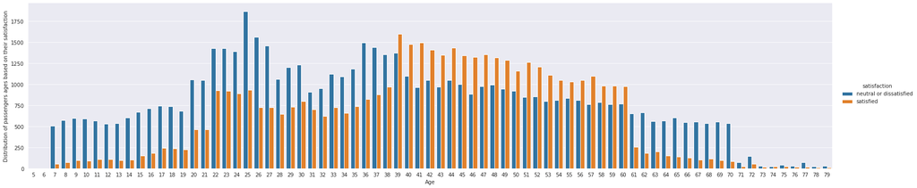

```python
# Barchart to Analysis distribution of passenger's Ages.

with sns.axes_style('darkgrid'):

    Age_bar = sns.catplot("Age", data=df, aspect=4.5, kind='count', hue='satisfaction', order=range(5, 80))

    Age_bar.set_ylabels('Distribution of passengers ages based on their satisfaction')
```

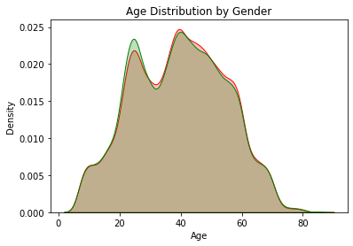

```python
# Distribution of passenger's ages based on gender

sns.kdeplot(df.loc[(df['Gender']=='Male'),'Age'], shade = True, color = 'red', label = 'Male')
sns.kdeplot(df.loc[(df['Gender']=='Female'),'Age'], shade = True, color = 'green', label = 'Female')
plt.title('Age Distribution by Gender')
```

#### Flight class and type of customer are checked with pie charts and then they are explained.

```python
#Checking proportion of passengers in terms of their Class

df.Class.value_counts()
```

```
Business    49665
Eco         46745
Eco Plus     7494
Name: Class, dtype: int64
```

```python
#Checking proportion of passengers in terms of their type

df['Customer Type'].value_counts()
```

```
Loyal Customer       84923
disloyal Customer    18981
Name: Customer Type, dtype: int64
```

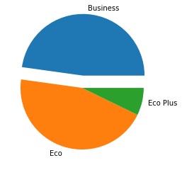

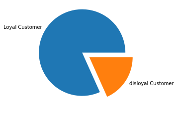

```python
plt.figure(0)
# Create first chart.

y = np.array([49665, 46745, 7494])
mylabels = ["Business", "Eco", "Eco Plus"]
myexplode = [0.2, 0, 0]

plt.pie(y, labels = mylabels, explode = myexplode)


plt.figure(1)
#Create second Chart.

y=np.array([84923,18981])
mylabels=["Loyal Customer","disloyal Customer"]
myexplode = [0.2,0]
plt.pie(y, labels = mylabels, explode = myexplode)


plt.show() #show all figures
```

#### Explanation:

The most proportion of passengers used "Eco" and "Eco Plus" types of flight. To be more specific, airline can earn more profit by focusing more attention on these type of passengers. On the other hand, most proportion of passengers were Loyal, actually they used airline more than once. We will perform analysis of these types of passengers in terms of their satisfaction in continue of project.

In below, analysis is performed for making comparison between the number of satisfied and dissatisfied passengers who used this airline.

#### Bar-chart and graph have one explanation

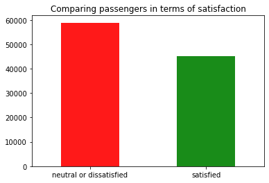

```python
# checking number of satisfied and dissatisfied passengers

figure = plt.figure(figsize = (6,4))
df.satisfaction.value_counts(normalize = False).plot(kind='bar',color= ['red','green'],alpha = 0.9,rot=0)
plt.title('Comparing passengers in terms of satisfaction')
plt.show()
```

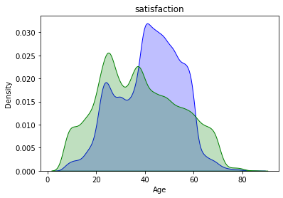

```python
sns.kdeplot(df.loc[(df['satisfaction']=='satisfied'),'Age'],shade = True,color ='Blue',label ='Personal Travel')
sns.kdeplot(df.loc[(df['satisfaction']=='neutral or dissatisfied'),'Age'],shade = True,color ='green',label ='Business travel')
plt.title('satisfaction')
```

#### Explanation:

We use bar charts at first to find frequency of people who are examined in terms of their satisfaction level after using airline. Then we use some other kinds of descriptive analytics tools like histogram chart and heat maps based on our criterias. Due to the number of colomuns we are going to show some charts in each figure and then each of them is explained, separately.

# 2.2.a. Figure one (4 Analysises)

In figure one, we analayzed our dataset considering four coloumns such as "Online boarding","Seat comfort", "Inflight entertainment" and "On-board service". Due to the number of features we used 4 analysis in a figure.

#### Bar-charts have explanation.

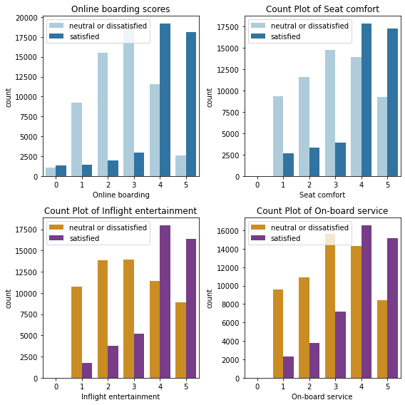

```python
plt.figure(figsize=(8,8))
plt.subplot(2,2,1)
sns.countplot(data=df, x="Online boarding" , hue="satisfaction", palette="Paired")
plt.title("Online boarding scores")
plt.legend()

plt.subplot(2,2,2)
sns.countplot(data=df, x="Seat comfort" , hue="satisfaction", palette="Paired")
plt.title("Count Plot of Seat comfort")
plt.legend()

plt.subplot(2,2,3)
sns.countplot(data=df, x="Inflight entertainment" , hue="satisfaction", palette="CMRmap_r")
plt.title("Count Plot of Inflight entertainment")
plt.legend()

plt.subplot(2,2,4)
sns.countplot(data=df, x="On-board service" , hue="satisfaction", palette="CMRmap_r")
plt.title("Count Plot of On-board service")
plt.legend()
plt.tight_layout()
plt.show()
```

## Explanation of figure one:

Figure one is consisted of four bar charts and in this section we are going to explain and analysis each of them, respectively.

#### Online boarding:

Totally the performance of airline was not bad in this regard, even the most proportion of passengers who were dissatisfied chose score 3 in survey while almost 2500 of passengers who were dissatisfied, chose 5 out of 5. As expectations, satisfied passengers chose 4 and 5, more than other choices. Actually, almost 37000 of satisfied passengers, were satisfied about online boarding service,too. On the other hand, almost 9000 of satisfied passengers, were not satisfied about this service during their experience with the airline.

#### Seat comfort:

In this scope of analysis, number of satisfied passengers who had not intresting experience, did not have change significantly. Actually, almost 9000 of satisfied passengers chose scores lower than 4 in this regard while none of them chose score 0. Constantly, almost 10000 as well as 15000 of dissatisfied of passengers had excellent and good experience about their seat, respectively. Also, none of dissatisfied passengers chose 0, actually they had a minimum percent af satisfaction.

#### Inflight entertainment:

This service should be more considered in airline because some proportion of passengers who even were satisfied of their experiences about the airline, identified 3 and lower for scores.

#### On-board service:

Number of dissatisfied passengers was considerable. But most proportion of dissatisfied passengers had "middle" opinion about the On-board service and most proportion of satisfied passengers gave "4".

# 2.2.b. Figure two (4 Analysises)

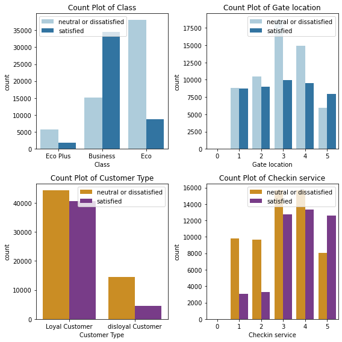

```python
plt.figure(figsize=(8,8))
plt.subplot(2,2,1)
sns.countplot(data=df, x="Class" , hue="satisfaction", palette="Paired")
plt.title("Count Plot of Class")
plt.legend()

plt.subplot(2,2,2)
sns.countplot(data=df, x="Gate location" , hue="satisfaction", palette="Paired")
plt.title("Count Plot of Gate location")
plt.legend()

plt.subplot(2,2,3)
sns.countplot(data=df, x="Customer Type" , hue="satisfaction", palette="CMRmap_r")
plt.title("Count Plot of Customer Type")
plt.legend()

plt.subplot(2,2,4)
sns.countplot(data=df, x="Checkin service" , hue="satisfaction", palette="CMRmap_r")
plt.title("Count Plot of Checkin service")
plt.legend()
plt.tight_layout()
plt.show()
```

#### Class:

Most proportion of dissatisfied passnegers had Eco type of flight. It should be pointed out most passengers who were satisfied used Business type of flight. Just in Business type of flight the number of satisfied passnegers were more.

#### Gate Location:

Almost about this feature the number of satisfied and dissatified passengers was equal except among passneger who gave score "3" and "4". In these score, proportion of dissatisfying was more.

#### Customer Type:

There is a considerable difference between number of Loyal and disloyal customer for this airline. But, between loyal and disloyal passnegers the number of dissatisfied were more rather than satisfied passengers.

#### Check-in Service:

The percentage of dissatisfied was absolutely more except proportion of passengers who gave just score "5".

# 2.2.c. Figure three (4 Analysises)

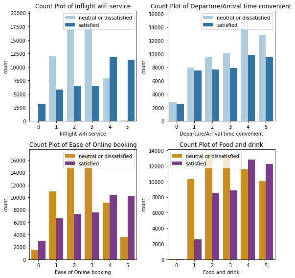

```python
plt.figure(figsize=(8,8))
plt.subplot(2,2,1)
sns.countplot(data=df, x="Inflight wifi service" , hue="satisfaction", palette="Paired")
plt.title("Count Plot of Inflight wifi service")
plt.legend()

plt.subplot(2,2,2)
sns.countplot(data=df, x="Departure/Arrival time convenient" , hue="satisfaction", palette="Paired")
plt.title("Count Plot of Departure/Arrival time convenient")
plt.legend()

plt.subplot(2,2,3)
sns.countplot(data=df, x="Ease of Online booking" , hue="satisfaction", palette="CMRmap_r")
plt.title("Count Plot of Ease of Online booking")
plt.legend()

plt.subplot(2,2,4)
sns.countplot(data=df, x="Food and drink" , hue="satisfaction", palette="CMRmap_r")
plt.title("Count Plot of Food and drink")
plt.legend()
plt.tight_layout()
plt.show()
```

#### Inflight wifi service:

Diffrences between dassatisfied and satisfied passnegers in this feature is much. Actually, almost 50000 of dissatisfied passengers did not have acceptable level of satisfaction about wifi.

#### Departure/Arrival time convenient:

In all scores, number of dissatisfied passnegers were more rather than satisfied passnegers.

#### Ease of online booking:

People giving rating 2 and 3 were most dissatisfied by the onine facility of booking the flight,rather people giving rating 4 and 5 were most satisfied by the online booking facilty.

#### Food and Drink:

people giving rating below 3 were most dissatisfied by the foods and drinks served in the plane while the people giving rating above 3 were satisfied more with the food and drinks.

# 2.2.d. Figure five ( 4 Analysises)

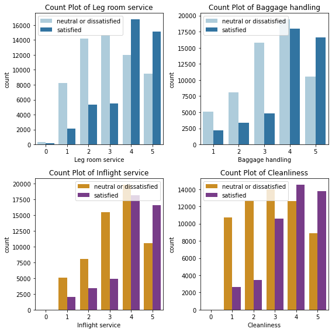

```python
plt.figure(figsize=(8,8))
plt.subplot(2,2,1)
sns.countplot(data=df, x="Leg room service" , hue="satisfaction", palette="Paired")
plt.title("Count Plot of Leg room service")
plt.legend()

plt.subplot(2,2,2)
sns.countplot(data=df, x="Baggage handling" , hue="satisfaction", palette="Paired")
plt.title("Count Plot of Baggage handling")
plt.legend()

plt.subplot(2,2,3)
sns.countplot(data=df, x="Inflight service" , hue="satisfaction", palette="CMRmap_r")
plt.title("Count Plot of Inflight service")
plt.legend()

plt.subplot(2,2,4)
sns.countplot(data=df, x="Cleanliness" , hue="satisfaction", palette="CMRmap_r")
plt.title("Count Plot of Cleanliness")
plt.legend()
plt.tight_layout()
plt.show()
```

#### Leg room service:

People giving rating below 3 are more dissatisfied by the leg room space availaible in the flightwhile people giving rating above 3 are more likely to get satisfied by the leg room space.

#### Baggage handling:

For the baggage service people giving ratings below 4 are most dissatisfied as compared to the people who gave 5 rating.Only those people are the most satisfied.

#### Inflight service:

Same is the case with the inflight service. People giving 4 starv and below rating are most dissatisfied with the inflight service while npeople who gave 5 star rating are most satisfied by the service.

#### Cleanliness:

in the case of cleanliness people of rating 3 and below are most dissatisfied with the cleanliness while the people with 4 and 5 rating are the most satisfied with the cleanliness.

# 2.2.e. Figure six

The point should be mentioned is that the " flight distance" had a considerable range due to this fact it should be analyzed observantly to find that what was the most proportion of ranges that passengers had travel by airline. But we have to check correlation between "Flight Distance" and "Type of travel".

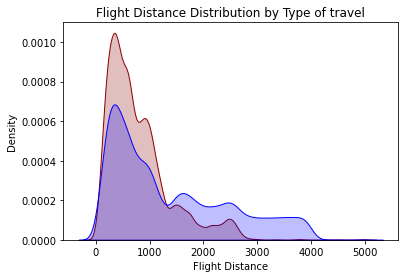

```python
sns.kdeplot(df.loc[(df['Type of Travel']=='Personal Travel'),'Flight Distance'],shade = True,color ='darkred',label ='Personal Travel')
sns.kdeplot(df.loc[(df['Type of Travel']=='Business travel'),'Flight Distance'],shade = True,color ='blue',label ='Business travel')
plt.title('Flight Distance Distribution by Type of travel')
```

The density of passenger who had flight distance between 0 and 1200 was more rather than passneger who had more flight distance. Actually, people had business travel had more flight distance.

# 2.2.f. Figure seven

In this graph we analyse type of flight based on flight distance. It is clear, people who had travel having distancr lower than 1000, prefered to buy Eco and Eco pluss types of flight. On the other hand, in long flight distance people prefered to have Business type of flight

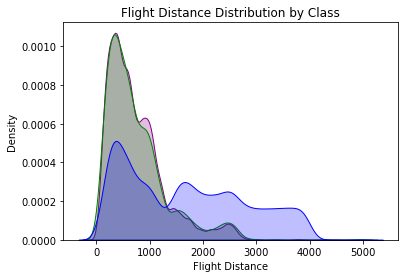

```python
sns.kdeplot(df.loc[(df['Class'] == 'Eco'), 'Flight Distance'], shade = True, color = 'purple', label = 'Eco')
sns.kdeplot(df.loc[(df['Class'] == 'Eco Plus'), 'Flight Distance'], shade = True, color = 'green', label = 'Eco Plus')
sns.kdeplot(df.loc[(df['Class'] == 'Business'), 'Flight Distance'], shade = True, color = 'blue', label = 'Business')
plt.title('Flight Distance Distribution by Class')
```

# 2.3 Figures eight (10 Analysies)

Briefly, about above bar chartswe can make histogram chart just based on the given score. In above charts and graphs together with bar charts there was a comparison between satisfied and dissatisied passengers while in below histograms we analyzed the number of given score in each feature.

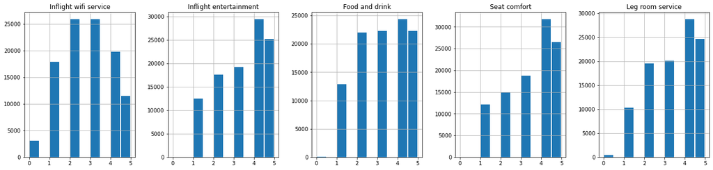

```python
fig, ax = plt.subplots(figsize = (23, 5), ncols = 5)
ax1 = df.hist('Inflight wifi service', ax = ax[0], rwidth = 0.9)
ax2 = df.hist('Inflight entertainment', ax = ax[1], rwidth = 0.9)
ax3 = df.hist('Food and drink', ax = ax[2], rwidth = 0.9)
ax4 = df.hist('Seat comfort', ax = ax[3], rwidth = 0.9)
ax5 = df.hist('Leg room service', ax = ax[4], rwidth = 0.9)
```

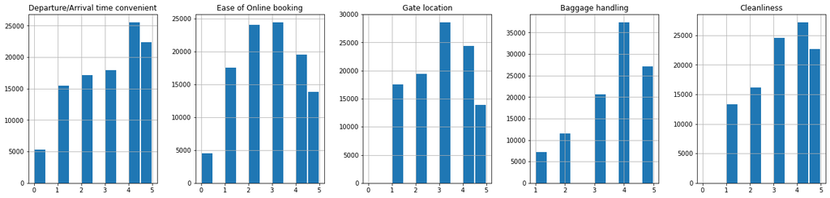

```python
fig, ax = plt.subplots(figsize = (23, 5), ncols = 5)
ax1 = df.hist('Departure/Arrival time convenient', ax = ax[0], rwidth = 0.9)
ax2 = df.hist('Ease of Online booking', ax = ax[1], rwidth = 0.9)
ax3 = df.hist('Gate location', ax = ax[2], rwidth = 0.9)
ax4 = df.hist('Baggage handling', ax = ax[3], rwidth = 0.9)
ax5 = df.hist('Cleanliness', ax = ax[4], rwidth = 0.9)
```

# 2.4 Prediction-Correlation between features

We need to identify correlation between features to have better analysis and efficient prediction about our dataset. Due to this fact, we used related chart including heat map, line graph and etc which are shown and explained in below. Actually we used "heatmap" as our prediction method for this project because apart from the prediction the correlation between features is clear on heatmap

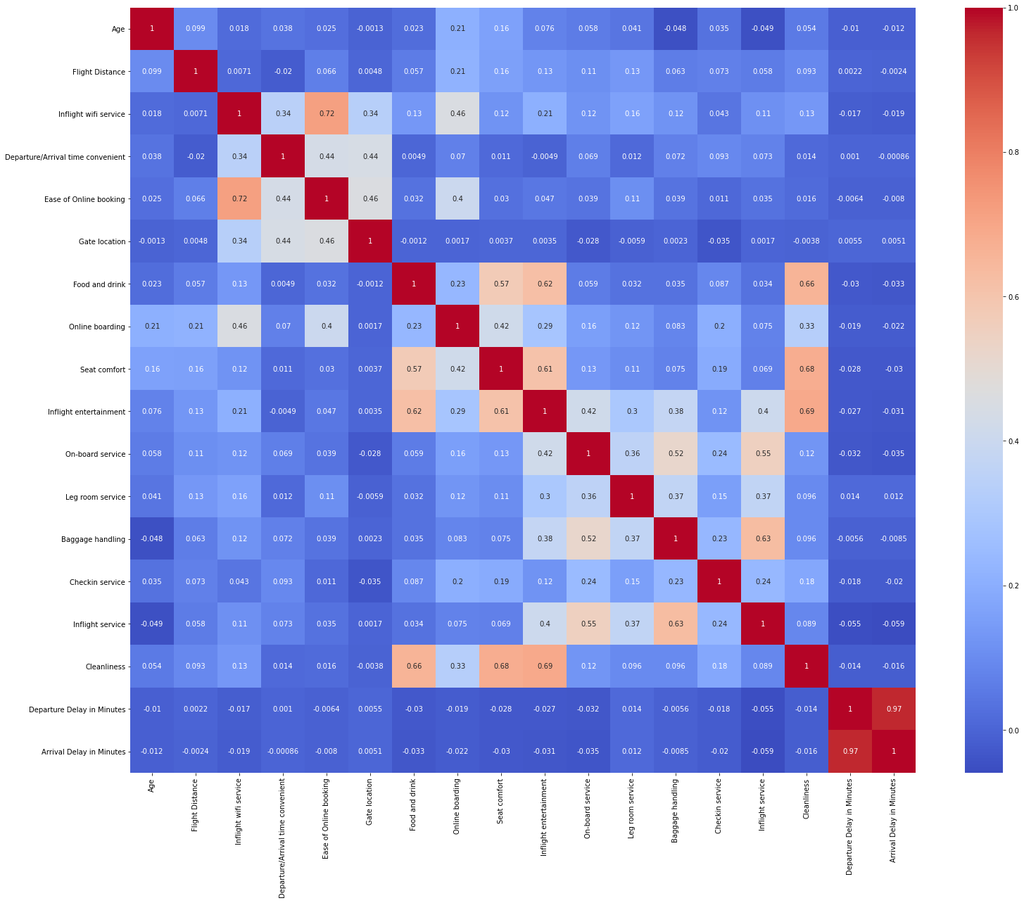

```python
#Finding Correlation between features

plt.figure(figsize=(25,20))
sns.heatmap(df.corr(),annot = True,cmap='coolwarm')
```

About the "Delay" scatter plot can be drawn to identify correlation better and it is shown below: It is clear there is a linear correlation between Arrival and Departure delay.

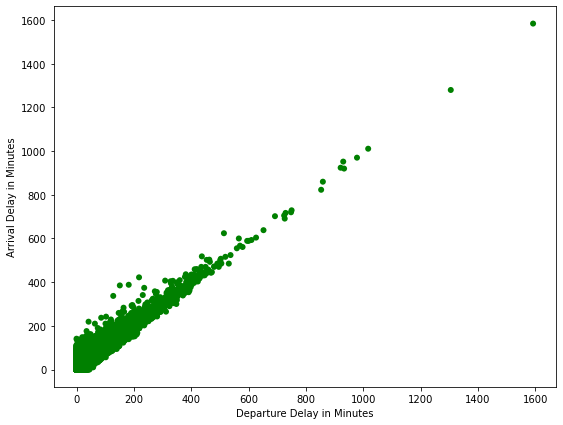

```python
plt.figure(figsize=(9,7))
sns.scatterplot('Departure Delay in Minutes','Arrival Delay in Minutes',data=df,color='g',edgecolor='none')
```

In addition we checked the dataset's correlation in terms of "age" and "delay" and "flight distance". It can enhance prediction power for future.

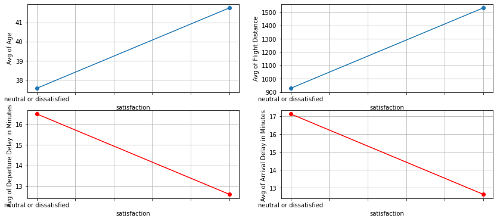

```python
# Checking features including

ax = plt.figure(figsize=(14,6))
plt.subplot(2,2,1)
df.groupby(['satisfaction'])['Age'].mean().plot(kind="line",color="C0",marker="o")
plt.ylabel("Avg of Age")
plt.grid(True)

plt.subplot(2,2,2)
df.groupby(['satisfaction'])['Flight Distance'].mean().plot(kind="line",color="C0",marker="o")
plt.ylabel("Avg of Flight Distance")
plt.grid(True)

plt.subplot(2,2,3)
df.groupby(['satisfaction'])['Departure Delay in Minutes'].mean().plot(kind="line",color="r",marker="o")
plt.ylabel("Avg of Departure Delay in Minutes ")
plt.grid(True)

plt.subplot(2,2,4)
df.groupby(['satisfaction'])['Arrival Delay in Minutes'].mean().plot(kind="line",color="r",marker="o")
plt.ylabel("Avg of Arrival Delay in Minutes ")
plt.grid(True)
plt.show()
```

### Important features:

Due to the numbers which are calculated on the heatmap, graph and charts, identifying features in terms of importance is not difficult. So, it can be listed as follows:

- Flight Distance
- Age
- Wifi
- Inflight Service
- Baggage Handling
- Type of travel
- Customer type
- Timeconv
- Seat comfort
- Leg room service
- Chek-in Service
- Class
- Online boarding
- Online booking
- Inflight entertainment
- On-board Service
- Cleanliness
- Food and Drink
- Gender

# 3. Conclusion

Our conclusion can be devided to some parts such as follows.

### Summary of findings:

A) In this project we found that level of customers' satisfaction can be depends on many features. Evaluating satisfaction in each of them can lead to efficient overview about customers' opinion and total satisfaction level about the airline.

B) We found that some features have considerable correlation with each other. To be more exact, "Ease_of_Online_booking" is highly correlated with "Inflight_wifi_service". Also "Inflight_service" is highly correlated with "Baggage_handling". On the other hand, some feature including "Delay" can have impressive impact on customers' satisfaction

C) We found the factor "Age" can make changes on passengers' expectations, actually passengers with different ages have different criterias for evaluating airline.

### Business implications for audience:

The project was done in manner that can be understandable for technical and non-technical audiences, contacts and readers. It is clear that airline for attracting more proportion of passengers should make its progress online, more than before. Passengers showed great passion for identifying their flight's details online. Apart from this, it can decrease airline expenses.

### Limitations of this project:

The main limitation that we faced was the number of passnegers, if it would be more, it could be better. Secondly, the number of evaluation were divided between 0 and 5 by the airline while it could be more range to better approximation. some factors was not considered in airline survey like "safety" that is important for every airline passenger.

### Answer of our questions:

In this part we answered our questions that were mentioned in abstract section, separately.

#### Descriptive questions:

1- Unfortunately, not. Airline could not get acceptable level of satisfaction based on the number of passengers. It is shown clearly on 'comparing passengers in terms of satisfaction' bar chart. most proportion of passengers were dissatisfied about their experineces in airline.

#### Diagnostic questions:

1- Because passengers need to feel conveninece when they want to have travel. To reach this convenience, many factors should be considered. These factor could be minor like the quality of drink in flight or could be more major like the amount of delay.

2- In this project, the analysis of variance could not be efficient as much as using heatmap. because all the passnegers were examined in a survey devided between 0 and 5 and due to the number of passnegers participated in survey, it could not be efficient for analysis and prediction.

### Suggestion for potential projects:

- Adding-up some other features for having better approximation such as "Safety" and "Child Service"
- Making wider the range of survey from 0 to 5. It could be better in terms of using some prediction models.
- After making the range of survey wider, analysis of variance can be made to have better prediction.

# Resources:

- https://www.kaggle.com/erntkn/satisfaction
- https://www.geeksforgeeks.org/plot-a-pie-chart-in-python-using-matplotlib/
- https://www.kaggle.com/vaishnavipatil4848/airline-passenger-satisfaction
- https://www.kaggle.com/nalkrolu/satisfaction-analysis-and-classification-airline
- https://datatofish.com/line-chart-python-matplotlib/
- https://www.kaggle.com/harrimansaragih/factor-analysis-of-airline-passenger-satisfaction
- https://www.kaggle.com/mohamedharris/airline-passenger-satisfaction
- https://www.kaggle.com/mohamedharris/airline-passenger-satisfaction